# Background

We’re going to explore a large data set or traffic crashes to learn about what factors are connected with injuries. We will use data from the city of [Chicago’s open data portal](https://data.cityofchicago.org/Transportation/Traffic-Crashes-Crashes/85ca-t3if/about_data). (This activity is derived from a [blog post](https://juliasilge.com/blog/chicago-traffic-model/) by Julia Silge)

```r
years_ago <- mdy("01/01/2022") # data from last 2 years. May take time to load!
crash_url <- glue::glue("https://data.cityofchicago.org/Transportation/Traffic-Crashes-Crashes/85ca-t3if?$where=CRASH_DATE >= '{years_ago}'")
crash_raw <- as_tibble(read.socrata(crash_url)) # a new way to read in data, don't worry about it!
```

This dataset is pretty crazy! Take a look at it in the viewer, and then let’s do some data munging to get it into a nicer form.

-create a variable called `injuries` which indicates if the crash involved injuries or not. -create an unknown category for missing `report_type`s -decide which other variables to keep

```r
crash_raw$report_type[crash_raw$report_type == ""] <- "UNKNOWN"

crash <- crash_raw %>%
  arrange(desc(crash_date)) %>%
  transmute(
    injuries = as.factor(if_else(injuries_total > 0, "injuries", "none")),
    latitude, longitude, report_type, weather_condition, damage, posted_speed_limit, prim_contributory_cause, crash_date
  )
```

## Exploratory Data Analysis

Here’s a few questions to get you started.

1. Take a look at crashes by latitude and longitude, colored by injuries. What do you notice?

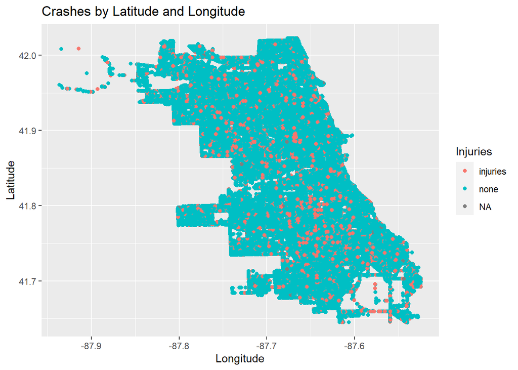

```r
crashfilter <- subset(crash, latitude >= 40)
ggplot(crashfilter, aes(x = longitude, y = latitude, color = injuries)) +
  geom_point() +
  labs(title = "Crashes by Latitude and Longitude",
       x = "Longitude",
       y = "Latitude",
       color = "Injuries")
```

It looks like a map of Chicago.

2. What are the most common contributing factors to a crash?

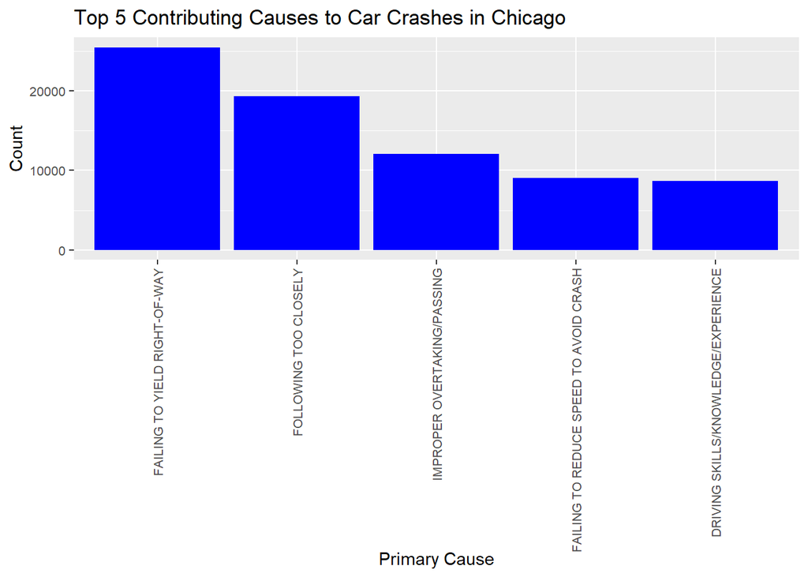

```r
most_common_causes <- table(crash$prim_contributory_cause)

common_causes_df <- as.data.frame(most_common_causes)

colnames(common_causes_df) <- c('Response', 'Count')

responses_to_exclude <- c("NOT APPLICABLE", "UNABLE TO DETERMINE")
common_causes_df <- common_causes_df[!(common_causes_df$Response %in% responses_to_exclude),]


common_causes_df <- common_causes_df[order(-common_causes_df$Count),]


top_5_responses <- head(common_causes_df, 5)




ggplot(top_5_responses, aes(x = reorder(Response, -Count), y = Count)) +
  geom_bar(stat = "identity", fill = 'blue') +
  labs(title = "Top 5 Contributing Causes to Car Crashes in Chicago",
       x = "Primary Cause",
       y = "Count") +
  theme(axis.text=element_text(size=8)) +
  theme(axis.text.x = element_text(angle = 90, vjust = 0.5, hjust=1))
```

3. How do crashes vary month by month? Compare crashes by month in 2022 to 2023.

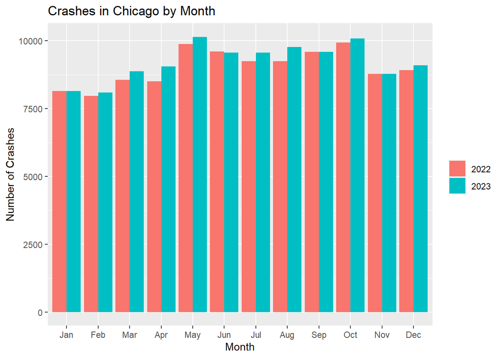

```r
crash$crash_date <- as.Date(crash$crash_date)

# Extract month and year information
crash$month <- format(crash$crash_date, "%m")
crash$year <- format(crash$crash_date, "%Y")

# Filter data for 2022 and 2023
data_2022 <- subset(crash, year == "2022")
data_2023 <- subset(crash, year == "2023")

# Count crashes by month for each year
crashes_2022 <- table(data_2022$month)
crashes_2023 <- table(data_2023$month)

# Create a data frame for plotting
crashes_data <- data.frame(
  Month = factor(month.abb, levels = month.abb),
  Crashes_2022 = crashes_2022,
  Crashes_2023 = crashes_2023
)

crashes_data <- crashes_data %>% select(-Crashes_2022.Var1, -Crashes_2023.Var1)
crashes_data <- crashes_data %>% rename('2022' = Crashes_2022.Freq, '2023' = Crashes_2023.Freq)

# Reshape data for plotting
library(tidyr)
crashes_data_long <- pivot_longer(crashes_data, cols = c('2022', '2023'), names_to = "Year", values_to = "Count")

# Create a bar plot using ggplot2
library(ggplot2)

ggplot(crashes_data_long, aes(x = Month, y = Count, fill = Year, group = Year)) +
  geom_bar(stat = "identity", position = "dodge") +
  labs(title = "Crashes in Chicago by Month",
       x = "Month",
       y = "Number of Crashes") +
  theme(legend.title = element_blank())
```

4. Are crashes more likely to cause injuries when it is rainy and dark? Use the variables `weather_condition` and `lighting_condition` to explore.

```r
crash_raw <- crash_raw %>%
  mutate(injuries_total = replace_na(injuries_total, 0))

summary_data <- crash_raw %>%
  group_by(weather_condition, lighting_condition) %>%
  summarise(total_injuries = sum(injuries_total))
```

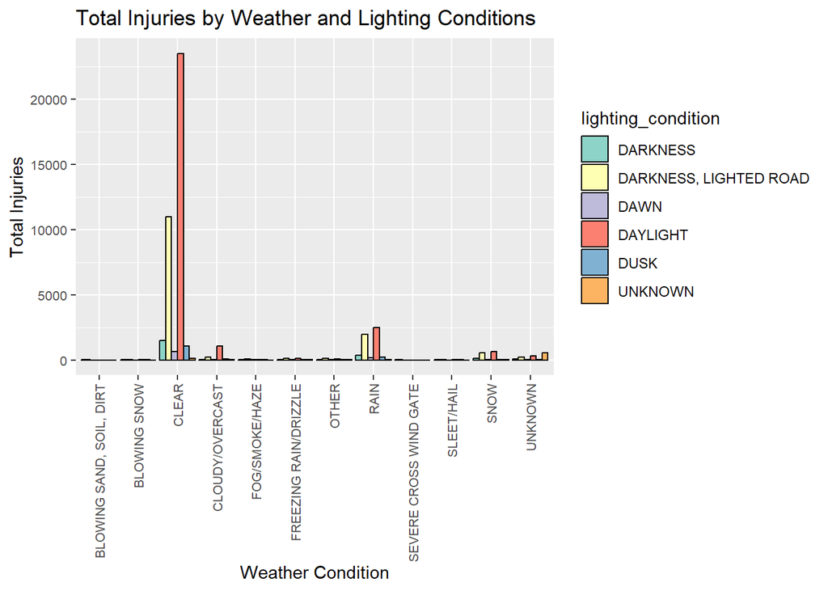

```r
ggplot(summary_data, aes(x = weather_condition, y = total_injuries, fill = lighting_condition)) +
  geom_bar(stat = "identity", position = "dodge", color = "black") +
  labs(title = "Total Injuries by Weather and Lighting Conditions",
       x = "Weather Condition",
       y = "Total Injuries") +
  scale_fill_brewer(palette = "Set3") +
  theme(axis.text=element_text(size=8)) +
  theme(axis.text.x = element_text(angle = 90, vjust = 0.5, hjust=1))
```

Rainy conditions seem to cause the most injuries other than other conditions other than clear weather, but total injury numbers don’t give much insight.

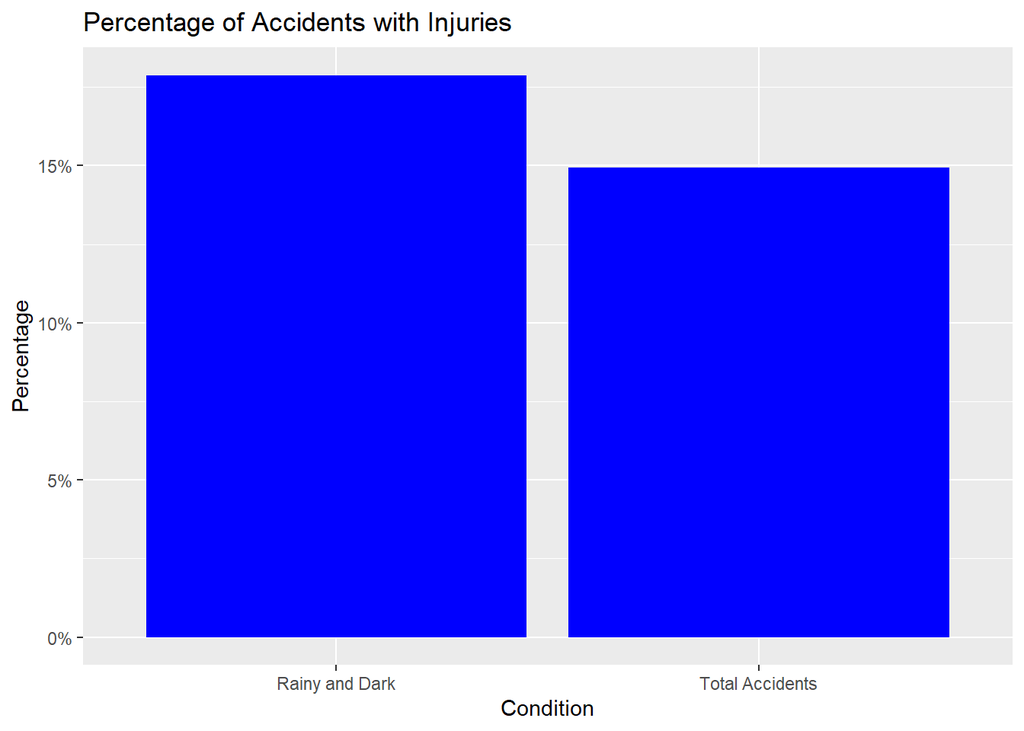

```r
subset_data <- subset(crash_raw, weather_condition == "RAIN" & lighting_condition == "DARKNESS")

# Calculate percentages
total_injuries_percentage <- sum(crash_raw$injuries_total > 0) / nrow(crash_raw) * 100
subset_injuries_percentage <- sum(subset_data$injuries_total > 0) / nrow(subset_data) * 100

# Create a bar chart
data <- data.frame(
  Condition = c("Total Accidents", "Rainy and Dark"),
  Percentage = c(total_injuries_percentage, subset_injuries_percentage)
)

ggplot(data, aes(x = Condition, y = Percentage)) +
  geom_bar(stat = "identity", fill = "blue") +
  labs(title = "Percentage of Accidents with Injuries",
       y = "Percentage",
       fill = "Condition") +
  scale_y_continuous(labels = scales::percent_format(scale = 1))
```

5. Choose a question you want to explore, and create an appropriate visual.

```r
crash_raw$crash_date <- as.POSIXct(crash_raw$crash_date)

# Extract the hour from 'crash_date'
crash_raw$hour <- format(crash_raw$crash_date, "%H")

# Create a summary table
summary_table <- crash_raw %>%
  group_by(damage, hour) %>%
  summarise(count = n())
```

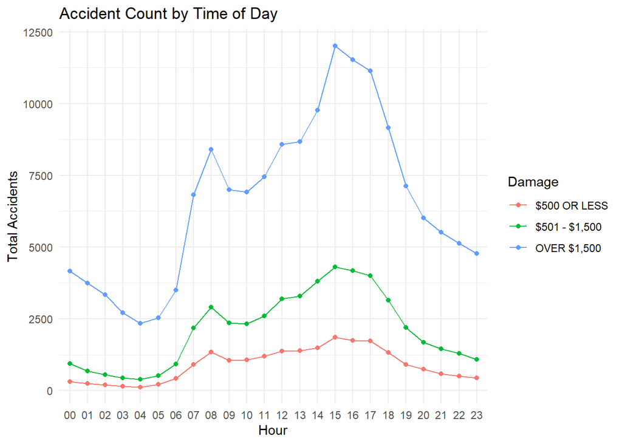

```r
# Create a line plot
ggplot(summary_table, aes(x = hour, y = count, color = damage, group = damage)) +
  geom_line() +
  geom_point() +
  labs(title = "Accident Count by Time of Day",
       x = "Hour",
       y = "Total Accidents",
       color = "Damage") +
  theme_minimal()
```

```r
crash$crash_date <- ymd(crash$crash_date)
crash$crash_day_of_week <- wday(crash$crash_date, label = TRUE, abbr=FALSE)
```

```r
crash <- crash[complete.cases(crash$injuries), ]
crash$crash_date <- ymd(crash$crash_date)
crash_dec_jan <- crash[month(crash$crash_date) %in% c(12, 1), ]


crash_dec_jan_summary <- crash_dec_jan %>%
  group_by(crash_day_of_week, injuries) %>%
  summarize(crashes_count = n())
crash_summary_pivot <- crash_dec_jan_summary %>%
  pivot_wider(names_from = injuries, values_from = crashes_count, values_fill = 0)
```